# Generalized linear models

Statistical Programming with R

## Packages and functions used

```r
library(magrittr) # pipes
library(DAAG) # data sets and functions
```

- `glm()` Generalized linear models
- `predict()` Obtain predictions based on a model
- `confint()` Obtain confidence intervals for model parameters
- `coef()` Obtain a model’s coefficients
- `DAAG::CVbinary()` Cross-validation for regression with a binary response

## Generalized linear models

## GLMs

The (general) linear model has \[Y_i=\alpha+\beta X_i+\epsilon_i\] where the \(\epsilon_i\) are IID, \(\epsilon_i \sim N(0,\sigma^2)\)

The *generalized* linear model relaxes the assumptions of linearity and normality:

\[f(\mathbb{E}[Y]) = \alpha + \beta X\]

Generalized linear models allow for a range of distributions (the exponential family) for the residuals and a variety of *link functions* \(f\).

## GLMs in R

We will work with the `glm` function in the `stats` package. If your needs grow more exotic, there are many alternative, GLM-related packages

```r
glm(formula, family = gaussian, data, weights, subset,
    na.action, start = NULL, etastart, mustart, offset,
    control = list(...), model = TRUE, method = "glm.fit",
    x = FALSE, y = TRUE, singular.ok = TRUE, contrasts = NULL, ...)
```

## Distributions and link functions supported by `glm`

The `family` argument gives the distribution of the residuals and the link function. For instance:

```r
family = gaussian(link = "identity") # This is the default for glm
family = poisson(link = "log")
```

Here, the link functions are the defaults and do not need to be specified. The `help(family)` file describes link functions accepted by `glm` – or you may specify your own.

## Distributions and link functions supported by `glm`

| Family | Default Link Function |
| --- | --- |
| gaussian | (link = “identity”) |
| binomial | (link = “logit”) |
| poisson | (link = “log”) |
| Gamma | (link = “inverse”) |
| inverse.gaussian | (link = “1/mu^2”) |
| quasi | (link = “identity”, variance = “constant”) |
| quasibinomial | (link = “logit”) |
| quasipoisson | (link = “log”) |

## Further extensions of the general linear model

- The `nlme` package for Gaussian (non)linear mixed-effects models
- The `mgcv` package for generalized additive (mixed) models
- The `lcmm` packages for latent class linear mixed models and joint analysis of longitudinal and time-to-event data

## Logistic regression

## Logistic regression

Logistic regression models log(odds) of a binary outcome as a linear function of the predictors:

\[ \text{logit}(p_i) = \log\frac{p_i}{1-p_i} = \alpha + \beta X_i \]

Where the outcome \(Y_i\) follows a binomial distribution with probability \(p_i\) of success.

## Logistic regression

We explore the `anesthetic` dataset: Thirty patients were given an anesthetic agent maintained at a predetermined level (conc) for 15 minutes before making an incision. It was then noted whether the patient moved, i.e. jerked or twisted

```r
anesthetic %>% head
```

```
##   move conc   logconc nomove
## 1    0  1.0 0.0000000      1
## 2    1  1.2 0.1823216      0
## 3    0  1.4 0.3364722      1
## 4    1  1.4 0.3364722      0
## 5    1  1.2 0.1823216      0
## 6    0  2.5 0.9162907      1
```

## Logistic regression

```r
glm(nomove ~ conc, family = binomial(link="logit"), data=anesthetic) %>% summary()
```

```
##
## Call:
## glm(formula = nomove ~ conc, family = binomial(link = "logit"),
##     data = anesthetic)
##
## Deviance Residuals:
##      Min        1Q    Median        3Q       Max
## -1.76666  -0.74407   0.03413   0.68666   2.06900
##
## Coefficients:
##             Estimate Std. Error z value Pr(>|z|)
## (Intercept)   -6.469      2.418  -2.675  0.00748 **
## conc           5.567      2.044   2.724  0.00645 **
## ---
## Signif. codes:  0 '***' 0.001 '**' 0.01 '*' 0.05 '.' 0.1 ' ' 1
##
## (Dispersion parameter for binomial family taken to be 1)
##
##     Null deviance: 41.455  on 29  degrees of freedom
## Residual deviance: 27.754  on 28  degrees of freedom
## AIC: 31.754
##
## Number of Fisher Scoring iterations: 5
```

## A different approach

Say we want to analyse counts in the aggregated table:

```r
anestot <- aggregate(anesthetic[, c("move","nomove")],
                     by = list(conc = anesthetic$conc), FUN = sum)
anestot
```

```
##   conc move nomove
## 1  0.8    6      1
## 2  1.0    4      1
## 3  1.2    2      4
## 4  1.4    2      4
## 5  1.6    0      4
## 6  2.5    0      2
```

## A different approach

```r
anestot$total <- apply(anestot[, c("move","nomove")], 1 , sum)
anestot$prop <- anestot$nomove / anestot$total
anestot
```

```
##   conc move nomove total      prop
## 1  0.8    6      1     7 0.1428571
## 2  1.0    4      1     5 0.2000000
## 3  1.2    2      4     6 0.6666667
## 4  1.4    2      4     6 0.6666667
## 5  1.6    0      4     4 1.0000000
## 6  2.5    0      2     2 1.0000000
```

## A different approach

```r
glm(prop ~ conc, family = binomial(link="logit"), weights = total, data=anestot) %>%
  summary()
```

```
##
## Call:
## glm(formula = prop ~ conc, family = binomial(link = "logit"),
##     data = anestot, weights = total)
##
## Deviance Residuals:
##        1         2         3         4         5         6
##  0.20147  -0.45367   0.56890  -0.70000   0.81838   0.04826
##
## Coefficients:
##             Estimate Std. Error z value Pr(>|z|)
## (Intercept)   -6.469      2.419  -2.675  0.00748 **
## conc           5.567      2.044   2.724  0.00645 **
## ---
## Signif. codes:  0 '***' 0.001 '**' 0.01 '*' 0.05 '.' 0.1 ' ' 1
##
## (Dispersion parameter for binomial family taken to be 1)
##
##     Null deviance: 15.4334  on 5  degrees of freedom
## Residual deviance:  1.7321  on 4  degrees of freedom
## AIC: 13.811
##
## Number of Fisher Scoring iterations: 5
```

## Logistic multiple regression

We analyse the `frogs` dataset, which details the presence or absence of the Southern Corroboree frog from a number of reference points in the Snowy Mountains area of New South Wales, Australia

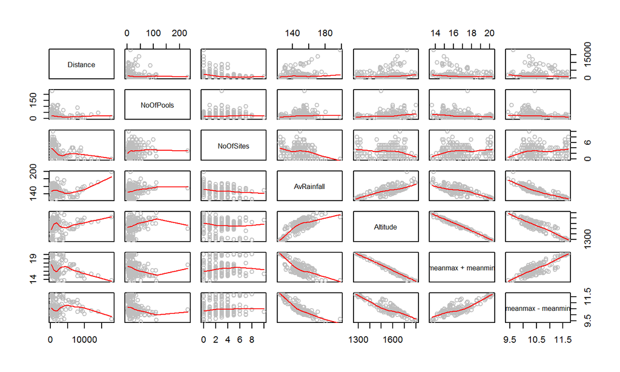

## Logistic multiple regression

Code for the previous slide:

```r
with(frogs, pairs(cbind(distance, NoOfPools, NoOfSites, avrain, altitude,
                        meanmax+meanmin, meanmax-meanmin),
                  col = "gray", panel = panel.smooth,
                  labels = c("Distance", "NoOfPools",
                             "NoOfSites", "AvRainfall", "Altitude",
                             "meanmax + meanmin", "meanmax - meanmin")))
```

## Logistic multiple regression

```
##
## Call:
## glm(formula = pres.abs ~ log(distance) + log(NoOfPools) + NoOfSites +
##     avrain + I(meanmax + meanmin) + I(meanmax - meanmin), family = binomial,
##     data = frogs)
##
## Deviance Residuals:
##     Min       1Q   Median       3Q      Max
## -1.9763  -0.7189  -0.2786   0.7970   2.5745
##
## Coefficients:
##                        Estimate Std. Error z value Pr(>|z|)
## (Intercept)          18.2688999 16.1381912   1.132  0.25762
## log(distance)        -0.7583198  0.2558117  -2.964  0.00303 **
## log(NoOfPools)        0.5708953  0.2153335   2.651  0.00802 **
## NoOfSites            -0.0036201  0.1061469  -0.034  0.97279
## avrain                0.0007003  0.0411710   0.017  0.98643
## I(meanmax + meanmin)  1.4958055  0.3153152   4.744  2.1e-06 ***
## I(meanmax - meanmin) -3.8582668  1.2783921  -3.018  0.00254 **
## ---
## Signif. codes:  0 '***' 0.001 '**' 0.01 '*' 0.05 '.' 0.1 ' ' 1
##
## (Dispersion parameter for binomial family taken to be 1)
##
##     Null deviance: 279.99  on 211  degrees of freedom
## Residual deviance: 197.65  on 205  degrees of freedom
## AIC: 211.65
##
## Number of Fisher Scoring iterations: 5
```

## Logistic multiple regression

```
##
## Call:
## glm(formula = pres.abs ~ log(distance) + log(NoOfPools) + I(meanmax +
##     meanmin) + I(meanmax - meanmin), family = binomial, data = frogs)
##
## Deviance Residuals:
##     Min       1Q   Median       3Q      Max
## -1.9753  -0.7224  -0.2780   0.7974   2.5736
##
## Coefficients:
##                      Estimate Std. Error z value Pr(>|z|)
## (Intercept)           18.5268     5.2673   3.517 0.000436 ***
## log(distance)         -0.7547     0.2261  -3.338 0.000844 ***
## log(NoOfPools)         0.5707     0.2152   2.652 0.007999 **
## I(meanmax + meanmin)   1.4985     0.3088   4.853 1.22e-06 ***
## I(meanmax - meanmin)  -3.8806     0.9002  -4.311 1.63e-05 ***
## ---
## Signif. codes:  0 '***' 0.001 '**' 0.01 '*' 0.05 '.' 0.1 ' ' 1
##
## (Dispersion parameter for binomial family taken to be 1)
##
##     Null deviance: 279.99  on 211  degrees of freedom
## Residual deviance: 197.66  on 207  degrees of freedom
## AIC: 207.66
##
## Number of Fisher Scoring iterations: 5
```

## Fitted values

```r
frogs.glm <- glm(pres.abs ~ log(distance) + log(NoOfPools)
                 + I(meanmax + meanmin) + I(meanmax - meanmin),
                 family = binomial,
                 data = frogs)
frogs.glm %>% fitted() %>% head()
```

```
##         2         3         4         5         6         7
## 0.9416691 0.9259228 0.9029415 0.8119619 0.9314070 0.7278038
```

```r
frogs.glm %>% predict(type = "response") %>% head()
```

```
##         2         3         4         5         6         7
## 0.9416691 0.9259228 0.9029415 0.8119619 0.9314070 0.7278038
```

```r
frogs.glm %>% predict(type = "link") %>% head() # Scale of linear predictor
```

```
##         2         3         4         5         6         7
## 2.7815212 2.5256832 2.2303441 1.4628085 2.6085055 0.9835086
```

## Fitted values with approximate SE’s

```r
pred <- frogs.glm %>%
  predict(type = "link", se.fit = TRUE)
data.frame(fit = pred$fit, se = pred$se.fit) %>% head()
```

```
##         fit        se
## 2 2.7815212 0.6859612
## 3 2.5256832 0.4851882
## 4 2.2303441 0.4381720
## 5 1.4628085 0.4805175
## 6 2.6085055 0.5290599
## 7 0.9835086 0.3900549
```

## Confidence intervals for the \(\beta\)

```r
frogs.glm %>% confint()
```

```
##                           2.5 %     97.5 %
## (Intercept)           8.5807639 29.3392400
## log(distance)        -1.2157643 -0.3247928
## log(NoOfPools)        0.1628001  1.0106909
## I(meanmax + meanmin)  0.9219804  2.1385678
## I(meanmax - meanmin) -5.7299615 -2.1868793
```

```r
frogs.glm %>% coef()
```

```
##          (Intercept)        log(distance)       log(NoOfPools)
##           18.5268418           -0.7546587            0.5707174
## I(meanmax + meanmin) I(meanmax - meanmin)
##            1.4984905           -3.8805856
```

## Cross validating predictive power

```r
set.seed(123)
frogs.glm <- glm(pres.abs ~ log(distance) + log(NoOfPools),
                 family = binomial, data = frogs)
cv <- CVbinary(frogs.glm)
```

```
##
## Fold:  3 10 2 6 5 4 9 8 7 1
## Internal estimate of accuracy = 0.759
## Cross-validation estimate of accuracy = 0.745
```

The cross-validation measure is the proportion of predictions over the folds that are correct.

## Cross validating predictive power

```r
frogs.glm2 <- glm(pres.abs ~ log(distance) + log(NoOfPools)
                 + I(meanmax + meanmin) + I(meanmax - meanmin),
                 family = binomial, data = frogs)
cv <- CVbinary(frogs.glm2)
```

```
##
## Fold:  1 5 9 8 7 2 10 6 4 3
## Internal estimate of accuracy = 0.778
## Cross-validation estimate of accuracy = 0.778
```

## Cross validating predictive power

```r
frogs.glm2 <- glm(pres.abs ~ log(distance) + log(NoOfPools)
                 + I(meanmax + meanmin) + I(meanmax - meanmin),
                 family = binomial, data = frogs)
cv <- CVbinary(frogs.glm2, nfolds = 5)
```

```
##
## Fold:  3 2 4 5 1
## Internal estimate of accuracy = 0.778
## Cross-validation estimate of accuracy = 0.783
```